# Analyzing Healthcare Provider Shortage - Part 4/4

### Build Forest Based CART Model

To run our analysis, we will use the cleaned demographic and health expenditure data layer `demographic_healthexp_clean_allproviders`. The output of the model will be stored in a file geodatabase which can then be accessed to visualize the results.

Here, we created a 'Train Only' model with all predictors. The model is trained on 70% data and 30% data is excluded for validation. The model was run for 5 iterations.

Note that increasing the number of trees in the forest model will result in more accurate model prediction, but the model will take longer to calculate. Learn more about the parameters used and outputs generated by this model [here](https://pro.arcgis.com/en/pro-app/tool-reference/spatial-statistics/how-forest-works.htm).

```python
from arcpy.stats import Forest

# Workspace
arcpy.env.workspace
lyr_url = allprovider_layer.url

predictors = [['amerind_pop','false'],['asian_pop','false'],['asso_deg','false'],['avg_healthcare','false'],
              ['avg_healthinsurance','false'],['avg_hhinc','false'],['avg_hhsz','false'],['avg_labtest','false'],
              ['avg_medicalcare','false'],['avg_medicalsrvc','false'],['avg_medicare','false'],['avg_personalinsurance','false'],
              ['avg_presdrug','false'],['avg_socsecurity','false'],['bach_deg','false'],['grad_deg','false'],
              ['hisp_pop','false'],['median_age','false'],['minority_pop','false'],['otherace_pop','false'],
              ['percap_income','false'],['pop_density','false'],['some_college','false'],['unemp_rate','false'],
              ['white_pop','false']]

# Define model variables
prediction_type = 'TRAIN'
in_features = lyr_url
variable_predict = 'provider_count'
treat_variable_as_categorical = None
explanatory_variables = predictors
distance_features = None
explanatory_rasters = None
features_to_predict = None
output_features = None
output_raster = None
explanatory_variable_matching = None
explanatory_distance_matching = None
explanatory_rasters_matching = None
output_trained_features = 'RF_Output_Result1'
output_importance_table = 'RF_VImp_Result1'
use_raster_values = True
number_of_trees = 100
minimum_leaf_size = None
maximum_depth = None
sample_size = 100
random_variables = None
percentage_for_training = 30
output_classification_table = None
output_validation_table = None
compensate_sparse_categories = False
number_validation_runs = 5
calculate_uncertainty = False

# Run Model
Forest(prediction_type,in_features, variable_predict, treat_variable_as_categorical, explanatory_variables, distance_features,
       explanatory_rasters, features_to_predict, output_features, output_raster, explanatory_variable_matching,
      explanatory_distance_matching, explanatory_rasters_matching, output_trained_features, output_importance_table,
      use_raster_values, number_of_trees, minimum_leaf_size, maximum_depth, sample_size, random_variables,
       percentage_for_training, output_classification_table, output_validation_table, compensate_sparse_categories,
       number_validation_runs, calculate_uncertainty)
```

Output

| id | value |
| --- | --- |
| 0 |  |
| 1 |  |
| 2 | ./ArcGIS\home\Results.gdb\RF_Output_Result1 |
| 3 | .\ArcGIS\home\Results.gdb\RF_VImp_Result1 |
| 4 |  |
| 5 |  |
| 6 |  |

Messages

Start Time: Tuesday, August 18, 2020 11:18:47 AM  
Random Seed: 743240  
-------------- Model Characteristics ---------------  
Number of Trees 100  
Leaf Size 5  
Tree Depth Range 21-35  
Mean Tree Depth 24  
% of Training Available per Tree 100  
Number of Randomly Sampled Variables 8  
% of Training Data Excluded for Validation 30  
----------------- Model Out of Bag Errors -----------------  
Number of Trees 50 100  
MSE 3548137.480 3557138.319  
% of variation explained 89.876 89.850  
------------------ Top Variable Importance -------------------  
Variable Importance %  
bach_deg 19939112417.90 26  
grad_deg 16751463301.93 22  
asso_deg 10797452932.51 14  
white_pop 10407959333.70 14  
some_college 5983283750.09 8  
minority_pop 3769590765.62 5  
asian_pop 1757683683.45 2  
otherace_pop 1570518369.82 2  
hisp_pop 1149944355.78 2  
pop_density 931317892.05 1  
avg_hhsz 449321852.69 1  
avg_labtest 294453790.43 0  
unemp_rate 240548007.81 0  
amerind_pop 194586943.19 0  
median_age 176352561.41 0  
avg_medicalcare 171480757.12 0  
avg_hhinc 167152354.09 0  
avg_presdrug 155137159.98 0  
percap_income 150177406.71 0  
avg_healthinsurance 135636139.98 0  
----- Training Data: Regression Diagnostics ------  
R-Squared 0.980  
p-value 0.000  
Standard Error 0.003  
*Predictions for the data used to train the model compared to the observed categories for those features  
---- Validation Data: Regression Diagnostics -----  
R-Squared 0.806  
p-value 0.000  
Standard Error 0.010  
*Predictions for the test data (excluded from model training) compared to the observed values for those test features  
Median R2 0.806 was approximately reached at seed 600633  
------------------------- Explanatory Variable Range Diagnostics -------------------------  
Training Validation Training Validation  
Variable Minimum Maximum Minimum Maximum Share(a) Share(b)  
asian_pop 0.00 721646.00 0.00 1517296.00 0.48* 2.10  
amerind_pop 0.00 56871.00 0.00 98584.00 0.58* 1.73  
avg_hhsz 2.00 4.34 1.96 4.32 0.98* 0.99*  
avg_hhinc 36078.00 162801.00 36312.00 146887.00 1.00 0.87*  
hisp_pop 0.00 2035551.00 4.00 5043293.00 0.40* 1.00*  
median_age 23.20 62.50 23.60 58.60 1.00 0.89*  
minority_pop 4.00 3339578.00 9.00 7644196.00 0.44* 1.00*  
otherace_pop 0.00 712410.00 0.00 2305030.00 0.31* 3.24  
percap_income 9853.00 71106.00 12247.00 57556.00 1.00 0.74*  
pop_density 0.00 72736.20 0.10 38009.90 1.00 0.52*  
unemp_rate 0.10 27.90 0.00 23.20 1.00* 0.83*  
white_pop 65.00 2859209.00 205.00 5019340.00 0.57* 1.00*  
some_college 22.00 690225.00 106.00 1300786.00 0.53* 1.00*  
asso_deg 5.00 237028.00 33.00 469649.00 0.50* 1.00*  
bach_deg 2.00 830433.00 38.00 1445895.00 0.57* 1.00*  
grad_deg 0.00 552050.00 19.00 782758.00 0.71* 1.00*  
avg_healthcare 2821.51 10690.41 2979.78 9276.07 1.00 0.80*  
avg_healthinsurance 1871.50 6873.42 1942.71 6168.19 1.00 0.84*  
avg_medicare 342.05 1501.33 358.05 1150.11 1.00 0.68*  
avg_medicalcare 950.01 3816.99 1033.36 3107.89 1.00 0.72*  
avg_medicalsrvc 496.89 1955.37 523.61 1747.84 1.00 0.84*  
avg_labtest 25.87 149.41 30.83 114.46 1.00 0.68*  
avg_presdrug 73.65 298.34 76.64 228.55…

### Get Variable Importance

```python
# RF Vimp Table
rf_df = pd.DataFrame.spatial.from_table(os.path.join(arcpy.env.workspace,output_importance_table))
rf_df.head()
```

|  | OBJECTID | ASIAN_POP | AMERIND_POP | AVG_HHSZ | AVG_HHINC | HISP_POP | MEDIAN_AGE | MINORITY_POP | OTHERACE_POP | PERCAP_INCOME | POP_DENSITY | UNEMP_RATE | WHITE_POP | SOME_COLLEGE | ASSO_DEG | BACH_DEG | GRAD_DEG | AVG_HEALTHCARE | AVG_HEALTHINSURANCE | AVG_MEDICARE | AVG_MEDICALCARE | AVG_MEDICALSRVC | AVG_LABTEST | AVG_PRESDRUG | AVG_PERSONALINSURANCE | AVG_SOCSECURITY | BEST_ITE |
| --- | --- | --- | --- | --- | --- | --- | --- | --- | --- | --- | --- | --- | --- | --- | --- | --- | --- | --- | --- | --- | --- | --- | --- | --- | --- | --- | --- |
| 0 | 1 | 1.936236e+09 | 3.626429e+08 | 3.493813e+08 | 1.125670e+08 | 1.250103e+09 | 1.173539e+08 | 4.140227e+09 | 6.644813e+08 | 1.448598e+08 | 7.810601e+08 | 1.923894e+08 | 7.744006e+09 | 7.352001e+09 | 7.441370e+09 | 1.640525e+10 | 1.491561e+10 | 8.568482e+07 | 7.602678e+07 | 1.409397e+08 | 1.779115e+08 | 1.250645e+08 | 1.550210e+08 | 1.979505e+08 | 1.010077e+08 | 8.123558e+07 | Iterations |
| 1 | 2 | 2.433282e+09 | 3.596755e+08 | 5.197042e+08 | 8.798179e+07 | 7.996029e+08 | 8.551507e+07 | 3.733401e+09 | 1.230084e+09 | 2.092976e+08 | 8.595931e+08 | 2.186328e+08 | 7.824331e+09 | 7.049030e+09 | 3.981829e+09 | 1.680595e+10 | 1.614554e+10 | 9.478313e+07 | 1.280119e+08 | 8.784919e+07 | 8.976733e+07 | 8.299869e+07 | 1.931147e+08 | 1.128664e+08 | 1.231691e+08 | 1.423122e+08 | Iterations |
| 2 | 3 | 6.599357e+09 | 3.059011e+09 | 3.728035e+08 | 1.275330e+08 | 3.492286e+09 | 2.321379e+08 | 7.863340e+09 | 2.919583e+09 | 6.579626e+08 | 6.159041e+08 | 1.683346e+08 | 1.039170e+10 | 1.243282e+10 | 7.768626e+09 | 1.736604e+10 | 2.124281e+10 | 1.431652e+08 | 1.175526e+08 | 1.172117e+08 | 1.422636e+08 | 1.450450e+08 | 1.939403e+08 | 1.784143e+08 | 1.297512e+08 | 1.678500e+08 | Best Iteration |
| 3 | 4 | 1.757684e+09 | 1.945869e+08 | 4.493219e+08 | 1.671524e+08 | 1.149944e+09 | 1.763526e+08 | 3.769591e+09 | 1.570518e+09 | 1.501774e+08 | 9.313179e+08 | 2.405480e+08 | 1.040796e+10 | 5.983284e+09 | 1.079745e+10 | 1.993911e+10 | 1.675146e+10 | 1.288261e+08 | 1.356361e+08 | 1.155745e+08 | 1.714808e+08 | 1.001931e+08 | 2.944538e+08 | 1.551372e+08 | 8.507679e+07 | 8.355390e+07 | Iterations |
| 4 | 5 | 2.814250e+09 | 1.713711e+08 | 4.762753e+08 | 1.089614e+08 | 9.045489e+08 | 1.936031e+08 | 4.892379e+09 | 8.828760e+08 | 1.527177e+08 | 7.046872e+08 | 3.028327e+08 | 9.538610e+09 | 1.130780e+10 | 1.121870e+10 | 1.794521e+10 | 1.795797e+10 | 1.915149e+08 | 1.026670e+08 | 1.464976e+08 | 1.400921e+08 | 1.150179e+08 | 2.381621e+08 | 1.880367e+08 | 9.893507e+07 | 1.269060e+08 | Iterations |

```python
rf_df.shape
```

```
(5, 27)
```

### Plot Variable Importance

```python
data = rf_df.drop(['OBJECTID','BEST_ITE'],axis=1)
data
```

|  | ASIAN_POP | AMERIND_POP | AVG_HHSZ | AVG_HHINC | HISP_POP | MEDIAN_AGE | MINORITY_POP | OTHERACE_POP | PERCAP_INCOME | POP_DENSITY | UNEMP_RATE | WHITE_POP | SOME_COLLEGE | ASSO_DEG | BACH_DEG | GRAD_DEG | AVG_HEALTHCARE | AVG_HEALTHINSURANCE | AVG_MEDICARE | AVG_MEDICALCARE | AVG_MEDICALSRVC | AVG_LABTEST | AVG_PRESDRUG | AVG_PERSONALINSURANCE | AVG_SOCSECURITY |
| --- | --- | --- | --- | --- | --- | --- | --- | --- | --- | --- | --- | --- | --- | --- | --- | --- | --- | --- | --- | --- | --- | --- | --- | --- | --- |
| 0 | 1.936236e+09 | 3.626429e+08 | 3.493813e+08 | 1.125670e+08 | 1.250103e+09 | 1.173539e+08 | 4.140227e+09 | 6.644813e+08 | 1.448598e+08 | 7.810601e+08 | 1.923894e+08 | 7.744006e+09 | 7.352001e+09 | 7.441370e+09 | 1.640525e+10 | 1.491561e+10 | 8.568482e+07 | 7.602678e+07 | 1.409397e+08 | 1.779115e+08 | 1.250645e+08 | 1.550210e+08 | 1.979505e+08 | 1.010077e+08 | 8.123558e+07 |
| 1 | 2.433282e+09 | 3.596755e+08 | 5.197042e+08 | 8.798179e+07 | 7.996029e+08 | 8.551507e+07 | 3.733401e+09 | 1.230084e+09 | 2.092976e+08 | 8.595931e+08 | 2.186328e+08 | 7.824331e+09 | 7.049030e+09 | 3.981829e+09 | 1.680595e+10 | 1.614554e+10 | 9.478313e+07 | 1.280119e+08 | 8.784919e+07 | 8.976733e+07 | 8.299869e+07 | 1.931147e+08 | 1.128664e+08 | 1.231691e+08 | 1.423122e+08 |
| 2 | 6.599357e+09 | 3.059011e+09 | 3.728035e+08 | 1.275330e+08 | 3.492286e+09 | 2.321379e+08 | 7.863340e+09 | 2.919583e+09 | 6.579626e+08 | 6.159041e+08 | 1.683346e+08 | 1.039170e+10 | 1.243282e+10 | 7.768626e+09 | 1.736604e+10 | 2.124281e+10 | 1.431652e+08 | 1.175526e+08 | 1.172117e+08 | 1.422636e+08 | 1.450450e+08 | 1.939403e+08 | 1.784143e+08 | 1.297512e+08 | 1.678500e+08 |
| 3 | 1.757684e+09 | 1.945869e+08 | 4.493219e+08 | 1.671524e+08 | 1.149944e+09 | 1.763526e+08 | 3.769591e+09 | 1.570518e+09 | 1.501774e+08 | 9.313179e+08 | 2.405480e+08 | 1.040796e+10 | 5.983284e+09 | 1.079745e+10 | 1.993911e+10 | 1.675146e+10 | 1.288261e+08 | 1.356361e+08 | 1.155745e+08 | 1.714808e+08 | 1.001931e+08 | 2.944538e+08 | 1.551372e+08 | 8.507679e+07 | 8.355390e+07 |
| 4 | 2.814250e+09 | 1.713711e+08 | 4.762753e+08 | 1.089614e+08 | 9.045489e+08 | 1.936031e+08 | 4.892379e+09 | 8.828760e+08 | 1.527177e+08 | 7.046872e+08 | 3.028327e+08 | 9.538610e+09 | 1.130780e+10 | 1.121870e+10 | 1.794521e+10 | 1.795797e+10 | 1.915149e+08 | 1.026670e+08 | 1.464976e+08 | 1.400921e+08 | 1.150179e+08 | 2.381621e+08 | 1.880367e+08 | 9.893507e+07 | 1.269060e+08 |

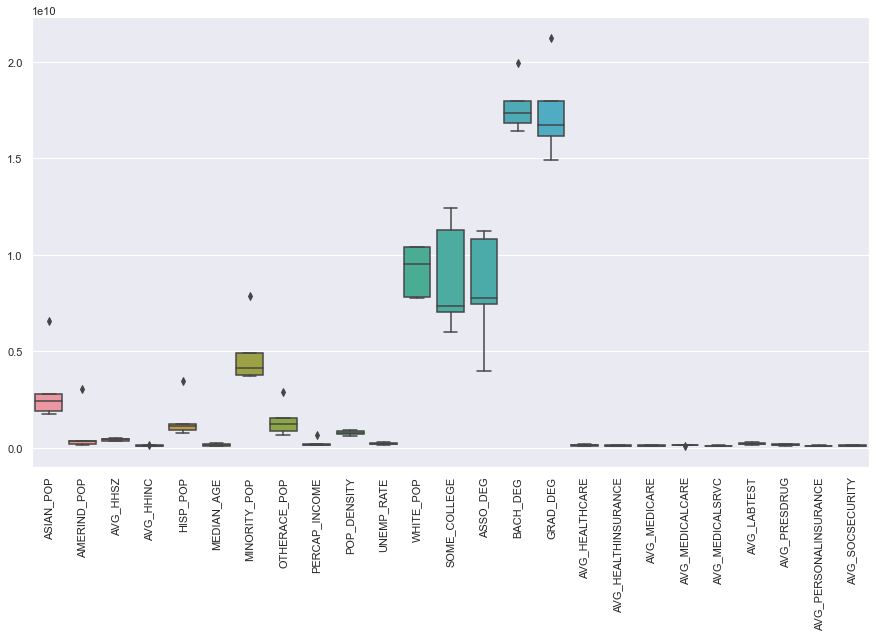

```python
# Plot Importance
sns.set(rc={'figure.figsize':(15,8.27)})
data = rf_df.drop(['OBJECTID','BEST_ITE'],axis=1)
g = sns.boxplot(data = data)
plt.xticks(rotation=90);
```

> We ran 5 iterations of Random Forest model. The box plot shows variable importance of each variable and how importance varies for each iteration.

#### Plot Best Iteration

```python
# Create dataframe for Best Iteration
best = rf_df[rf_df['BEST_ITE']=='Best Iteration']
best
```

|  | OBJECTID | ASIAN_POP | AMERIND_POP | AVG_HHSZ | AVG_HHINC | HISP_POP | MEDIAN_AGE | MINORITY_POP | OTHERACE_POP | PERCAP_INCOME | POP_DENSITY | UNEMP_RATE | WHITE_POP | SOME_COLLEGE | ASSO_DEG | BACH_DEG | GRAD_DEG | AVG_HEALTHCARE | AVG_HEALTHINSURANCE | AVG_MEDICARE | AVG_MEDICALCARE | AVG_MEDICALSRVC | AVG_LABTEST | AVG_PRESDRUG | AVG_PERSONALINSURANCE | AVG_SOCSECURITY | BEST_ITE |
| --- | --- | --- | --- | --- | --- | --- | --- | --- | --- | --- | --- | --- | --- | --- | --- | --- | --- | --- | --- | --- | --- | --- | --- | --- | --- | --- | --- |
| 2 | 3 | 6.599357e+09 | 3.059011e+09 | 3.728035e+08 | 1.275330e+08 | 3.492286e+09 | 2.321379e+08 | 7.863340e+09 | 2.919583e+09 | 6.579626e+08 | 6.159041e+08 | 1.683346e+08 | 1.039170e+10 | 1.243282e+10 | 7.768626e+09 | 1.736604e+10 | 2.124281e+10 | 1.431652e+08 | 1.175526e+08 | 1.172117e+08 | 1.422636e+08 | 1.450450e+08 | 1.939403e+08 | 1.784143e+08 | 1.297512e+08 | 1.678500e+08 | Best Iteration |

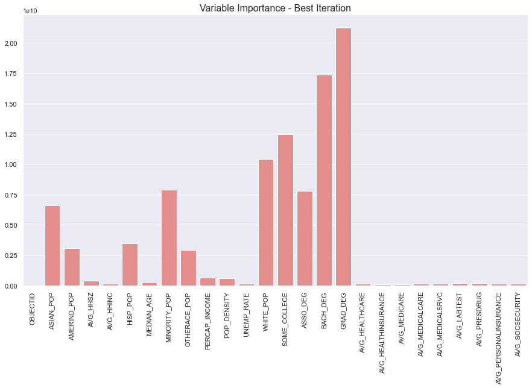

```python
# Create Plot
sns.set(rc={'figure.figsize':(15,8.27)})
sns.barplot(data=best, color='lightcoral')
plt.xticks(rotation=90)
plt.title('Variable Importance - Best Iteration', fontsize=16);
```

> The barplot shows variable importance of each variable for the best iteration. These variables will now be used in the next step of our analysis to understand how they vary with respect to provider count accross various counties in U.S.

## Local Bivariate Relationships (LBR) Model

Random Forest model generates variable importance and gives us important variables. However, this model does not tell us:

- the type of relationship and
- significance of relation of a predictor variable with respect to provider count.

To understand the type and significance of the relations of a predictor variable with respect to provider count at the County level, we will explore `Local Bivariate Relations (LBR) Model`.

Local Bivariate Relations analyzes two variables for statistically significant relationships using local entropy. The output can be used to visualize the type of relationship between two variables and explore how their relationship changes across counties.

We will use Local Bivariate Relations to study how relationship of important variables determined by Random Forest model change with respect to Provider Count accross various counties. Learn more about [Local Bivariate Relationships](https://pro.arcgis.com/en/pro-app/tool-reference/spatial-statistics/localbivariaterelationships.htm).

Two of the top five most important variables generated by Forest Based CART model are `Graduate Degree` and `White Population`. Let's build LBR models for Provider Count w.r.t these variables.

### Build Model - Provider Count and Graduate Degree

To run our analysis, we will use the cleaned demographic and health expenditure data layer `demographic_healthexp_clean_allproviders`. The output of the model will be stored in a file geodatabase which can then be accessed to visualize the results.

```python
from arcpy.stats import LocalBivariateRelationships

# Workspace
arcpy.env.workspace

# Get url of layer
lyr_url = allprovider_layer.url

# Define model variables
in_features = lyr_url
dependent_variable = 'provider_count'
explanatory_variable = 'grad_deg'
output_features = 'allprovider_grad_deg_LBR_Results1'
number_of_neighbors = 50
number_of_permutations = 99
enable_local_scatterplot_popups = 'NO_POPUP'
level_of_confidence = '95%'
apply_false_discovery_rate_fdr_correction = 'APPLY_FDR'
scaling_factor = 0.5

# Run Model
LocalBivariateRelationships(in_features, dependent_variable,explanatory_variable,output_features,number_of_neighbors,
                           number_of_permutations, enable_local_scatterplot_popups, level_of_confidence,
                            apply_false_discovery_rate_fdr_correction, scaling_factor)
```

Output

./ArcGIS\home\Results.gdb\allprovider_grad_deg_LBR_Results1

Messages

Start Time: Tuesday, August 18, 2020 11:44:27 AM  
------------ Categorical Summary -------------  
----------------------------------------------  
Description # of features % of features  
Positive Linear 1173 37.37  
Negative Linear 0 0.00  
Concave 881 28.07  
Convex 1085 34.57  
Undefined Complex 0 0.00  
Not Significant 0 0.00  
Total 3139 100.00  
----------------------------------------------  
--------- Entropy Results Summary ----------  
--------------------------------------------  
Description Min Max Mean Median  
Entropy 0.0518 0.8344 0.2526 0.2220  
p-value 0.0100 0.0100 0.0100 0.0100  
--------------------------------------------  
--------------- FDR Comparison ---------------  
----------------------------------------------  
Description # significant % significant  
Without FDR 3139 100.00  
FDR 3139 100.00  
----------------------------------------------  
Succeeded at Tuesday, August 18, 2020 11:44:57 AM (Elapsed Time: 29.96 seconds)

#### Access Model Results as Spatially Enabled Dataframe

```python
# Access GWR data from local
lbr_graddeg = pd.DataFrame.spatial.from_featureclass(os.path.join(arcpy.env.workspace,output_features))
lbr_graddeg.head()
```

|  | OBJECTID | SOURCE_ID | provider_count | grad_deg | ENTROPY | PVALUES | LBR_SIG | INTERCEPT | COEF_1 | PINTERCEPT | P_COEF_1 | P_COEF_2 | AICC | R2 | P_AICc | P_R2 | SIG_COEF | P_SIG_COEF | LBR_TYPE | SHAPE |
| --- | --- | --- | --- | --- | --- | --- | --- | --- | --- | --- | --- | --- | --- | --- | --- | --- | --- | --- | --- | --- |
| 0 | 1 | 1 | 1044.0 | 8931 | 0.502901 | 0.01 | 99% Confidence | 0.002812 | 0.458814 | -0.001986 | 0.796103 | -1.276968 | -247.674353 | 0.731508 | -256.013530 | 0.778649 | _* | _** | Concave | {"rings": [[[-8529642.2486, 4688391.039899997]... |
| 1 | 2 | 2 | 5.0 | 45 | 0.152911 | 0.01 | 99% Confidence | 0.000017 | 1.115497 | 0.000651 | 0.470873 | 31.338637 | -446.296708 | 0.802377 | -449.717733 | 0.820235 | _* | _** | Convex | {"rings": [[[-10120538.0346, 3896326.054200001... |
| 2 | 3 | 3 | 621.0 | 2153 | 0.352790 | 0.01 | 99% Confidence | -0.001671 | 1.237995 | 0.000260 | 0.938741 | 2.075127 | -329.879103 | 0.967074 | -333.452877 | 0.970141 | _* | _** | Convex | {"rings": [[[-9221715.5229, 5050074.560699999]... |
| 3 | 4 | 4 | 79.0 | 574 | 0.291545 | 0.01 | 99% Confidence | 0.000094 | 0.603532 | 0.000494 | 0.531451 | 0.468285 | -446.685913 | 0.985494 | -449.537319 | 0.986654 | _* | _** | Positive Linear | {"rings": [[[-9290699.0981, 4093591.7991999984... |
| 4 | 5 | 5 | 1210.0 | 5462 | 0.312456 | 0.01 | 99% Confidence | 0.000090 | 0.603811 | 0.000518 | 0.535677 | 0.441553 | -434.274636 | 0.981340 | -435.557616 | 0.982284 | _* | _** | Positive Linear | {"rings": [[[-9341355.0324, 3994505.8356000036... |

```python
lbr_graddeg.shape
```

```
(3139, 20)
```

```python
lbr_graddeg.LBR_TYPE.value_counts()
```

```
Positive Linear    1173
Convex             1085
Concave             881
Name: LBR_TYPE, dtype: int64
```

#### Plot Results on Map

[figure not shown]

```python
# Create Map
lbr_graddeg_map = gis.map('USA', 4)
lbr_graddeg_map
```

> The map shows how relationship of provider count varies with graduate degree holders for different counties. We can see:
> - Majority of the counties from North Dakota to Texas share a Convex or Positive Linear relation. This means that provider count increase with increasing graduate degree holders for these counties either linearly or polynomially.
> - Majority of East and West coast share a concave relation whcih means that provider count increases with graduater degree holders to a certain extent and then plateaus off at some point.

```python
lbr_graddeg_map.remove_layers()
lbr_graddeg.spatial.plot(map_widget=lbr_graddeg_map,
        renderer_type='u',  # for unique value renderer
        col='LBR_TYPE',  # numeric column to classify
        cmap='prism',  # color map to pick colors from for each class
        alpha=0.7,
        line_width=0.05) # specify opacity
```

```
True
```

```python
lbr_graddeg_map.legend = True
```

### Build Model - Provider Count and White Population

```python
from arcpy.stats import LocalBivariateRelationships

# Workspace
arcpy.env.workspace

# Get url of layer
lyr_url = allprovider_layer.url

# Define model variables
in_features = lyr_url
dependent_variable = 'provider_count'
explanatory_variable = 'white_pop'
output_features = 'allprovider_white_pop_LBR_Results1'
number_of_neighbors = 50
number_of_permutations = 99
enable_local_scatterplot_popups = 'NO_POPUP'
level_of_confidence = '95%'
apply_false_discovery_rate_fdr_correction = 'APPLY_FDR'
scaling_factor = 0.5

# Run Model
LocalBivariateRelationships(in_features, dependent_variable,explanatory_variable,output_features,number_of_neighbors,
                           number_of_permutations, enable_local_scatterplot_popups, level_of_confidence,
                            apply_false_discovery_rate_fdr_correction, scaling_factor)
```

Output

./ArcGIS\home\Results.gdb\allprovider_white_pop_LBR_Results1

Messages

Start Time: Tuesday, August 18, 2020 12:21:32 PM  
------------ Categorical Summary -------------  
----------------------------------------------  
Description # of features % of features  
Positive Linear 1047 33.35  
Negative Linear 0 0.00  
Concave 154 4.91  
Convex 1938 61.74  
Undefined Complex 0 0.00  
Not Significant 0 0.00  
Total 3139 100.00  
----------------------------------------------  
--------- Entropy Results Summary ----------  
--------------------------------------------  
Description Min Max Mean Median  
Entropy 0.0721 0.8752 0.2771 0.2497  
p-value 0.0100 0.0300 0.0100 0.0100  
--------------------------------------------  
--------------- FDR Comparison ---------------  
----------------------------------------------  
Description # significant % significant  
Without FDR 3139 100.00  
FDR 3139 100.00  
----------------------------------------------  
Succeeded at Tuesday, August 18, 2020 12:22:01 PM (Elapsed Time: 29.71 seconds)

#### Access Model Results as Spatially Enabled Dataframe

```python
# Access GWR data from local
lbr_whitepop = pd.DataFrame.spatial.from_featureclass(os.path.join(arcpy.env.workspace,output_features))
lbr_whitepop.head()
```

|  | OBJECTID | SOURCE_ID | provider_count | white_pop | ENTROPY | PVALUES | LBR_SIG | INTERCEPT | COEF_1 | PINTERCEPT | P_COEF_1 | P_COEF_2 | AICC | R2 | P_AICc | P_R2 | SIG_COEF | P_SIG_COEF | LBR_TYPE | SHAPE |
| --- | --- | --- | --- | --- | --- | --- | --- | --- | --- | --- | --- | --- | --- | --- | --- | --- | --- | --- | --- | --- |
| 0 | 1 | 1 | 1044.0 | 75625 | 0.462784 | 0.01 | 95% Confidence | -0.000806 | 0.964163 | -0.005220 | 1.439742 | -4.516278 | -222.974441 | 0.559980 | -222.721608 | 0.569225 | _* | _*_ | Positive Linear | {"rings": [[[-8529642.2486, 4688391.039899997]... |
| 1 | 2 | 2 | 5.0 | 494 | 0.172985 | 0.01 | 95% Confidence | -0.000454 | 0.991115 | -0.002512 | 2.194106 | -60.014844 | -401.267715 | 0.513645 | -407.081515 | 0.578266 | _* | *** | Concave | {"rings": [[[-10120538.0346, 3896326.054200001... |
| 2 | 3 | 3 | 621.0 | 51908 | 0.396061 | 0.01 | 95% Confidence | -0.010495 | 1.138899 | -0.004588 | 0.700722 | 2.639104 | -304.416195 | 0.945209 | -314.253990 | 0.956163 | ** | *** | Convex | {"rings": [[[-9221715.5229, 5050074.560699999]... |
| 3 | 4 | 4 | 79.0 | 16894 | 0.324165 | 0.01 | 95% Confidence | -0.003290 | 0.899859 | -0.000728 | 0.483160 | 5.162043 | -304.611806 | 0.751356 | -305.247346 | 0.760867 | ** | _** | Positive Linear | {"rings": [[[-9290699.0981, 4093591.7991999984... |
| 4 | 5 | 5 | 1210.0 | 31300 | 0.347374 | 0.01 | 95% Confidence | -0.003391 | 0.903693 | -0.000686 | 0.501848 | 4.935998 | -302.769404 | 0.741085 | -303.106776 | 0.749499 | ** | _*_ | Positive Linear | {"rings": [[[-9341355.0324, 3994505.8356000036... |

```python
lbr_whitepop.shape
```

```
(3139, 20)
```

```python
# Counts of different relationship types
lbr_whitepop.LBR_TYPE.value_counts()
```

```
Convex             1938
Positive Linear    1047
Concave             154
Name: LBR_TYPE, dtype: int64
```

#### Plot Results on Map

[figure not shown]

```python
# Create Map
lbr_whitepop_map = gis.map('USA', 4)
lbr_whitepop_map
```

> The map shows how relationship of provider count varies with white population for different counties. We can see:
> - For most of the counties in United States, the relationship is either Convex or Positive Linear which means that provider count increase with increasing white population either linearly or polynomially.
> - Southern parts of New Mexico, some counties in North Texas, Wyoming and Idaho have a concave relationship. This means that provider count increases to a certain extent and then plateaus off at some point.

```python
lbr_whitepop_map.remove_layers()
lbr_whitepop.spatial.plot(map_widget=lbr_whitepop_map,
        renderer_type='u',  # for class breaks renderer
        col='LBR_TYPE',  # numeric column to classify
        cmap='prism',  # color map to pick colors from for each class
        alpha=0.7,
        line_width=0.05) # specify opacity
```

```
True
```

```python
lbr_whitepop_map.legend = True
```

## Summary

To summarize, we:

1. Started with a `Base (OLS) Regression model` using all predictors:
   - Performed feature selection using `Lasso regularization` technique.
   - Created a `Global (OLS) Regression model` using selected features. The Global model helped us identify relationship between predictor variables and provider count at the country level.
1. Next, we created a `Geographically Weighted Regression (GWR) model`, to understand how different variables impact provider count accross different counties.
   - Here we plotted how provider count varies with average prescription drug prices and average household size across different counties.
1. To investigate non-linear relationship, we explored a non-parametric technique called `Forest Based Classification and Regression Trees model`.
   - The model returned `variable importance` of each variable.
1. To understand the type and significance of relationship of an individual predictor with respect to provider count, we created a `Local Bivariate Relations Model`.

## Conclusion

Studies [[10]](https://www.ncbi.nlm.nih.gov/books/NBK215247/) [[11]](https://pubmed.ncbi.nlm.nih.gov/22092449/) have shown that shortages of health providers limit patients' access to required treatment. In addition to provider supply, sociodemographic factors such as age, race, income and health insurance, are associated with access to care and health outcomes [[12]](https://link.springer.com/content/pdf/10.1007/s11606-010-1257-5.pdf) [[13]](https://www.ncbi.nlm.nih.gov/pmc/articles/PMC6406337/).

Public health stakeholders use numerous datasets to derive insights into the prevalence of healthcare providers and the impact of social determinants of health within their geographic service areas. The volume of available data can make it difficult for these stakeholders to determine how to best reach underserved populations [[14]](https://www.peacehealth.org/about-peacehealth/Pages/community-health-needs-assessment).

Our analysis integrates publicly available sociodemographic and provider location datasets [[15]](https://www.cms.gov/Regulations-and-Guidance/Administrative-Simplification/NationalProvIdentStand/DataDissemination.html) and uses advanced data analysis, visualization and machine learning techniques to show the variation of provider supply over different geographical areas along with a summary of the most distinctive and relevant sociodemographic features that are predictive of the variation in the selected area.

By better understanding these social determinants of health in their geographies, both government and non-governmental healthcare leaders can prioritize interventions around addressing underserved areas with healthcare provider shortages.

The analysis is designed to be easily extended with additional features or adapted to other provider specialties. The techniques defined in this analysis can support further data integrations including Medicare, Medicaid, and commercial insurance claims data to better understand actual patient utilization behavior and improve models.

To conclude, in this 4-part study we use Dask, ArcGIS API for Python, ArcGIS WebGIS stack, various spatial analysis tools and machine learning techniques to:

1. Read, clean and geocode ~ 5.7 million records of healthcare provider data.
2. Identify shortage areas for Overall, Mental health and OB-GYN healthcare providers in the U.S.
3. Identify sociodemographic and economic factors that influence access to providers.
4. Identify the influence of factors on access to providers.

## References

[1] https://en.wikipedia.org/wiki/Ordinary_least_squares [2] https://online.stat.psu.edu/stat501/lesson/7/7.3  
[3] https://sites.google.com/site/statisticsforspreadsheets/regression-modeling/influence-plot  
[4] https://online.stat.psu.edu/stat501/lesson/10/10.2  
[5] https://bookdown.org/max/FES/recursive-feature-elimination.html  
[6] https://towardsdatascience.com/ridge-lasso-and-elastic-net-regularization-7861ca575c64  
[7] https://towardsdatascience.com/feature-selection-using-random-forest-26d7b747597f  
[8] Feng C, Wang H, Lu N, et al. Log-transformation and its implications for data analysis [published correction appears in Gen Psychiatr. 2019 Sep 6;32(5):e100146corr1]. Shanghai Arch Psychiatry. 2014;26(2):105-109. doi:10.3969/j.issn.1002-0829.2014.02.009 [[Link]](https://www.ncbi.nlm.nih.gov/pmc/articles/PMC4120293/)  
[9] https://www.cscu.cornell.edu/news/statnews/stnews83.pdf  
[10] Institute of Medicine (US) National Cancer Policy Forum. Ensuring Quality Cancer Care through the Oncology Workforce: Sustaining Care in the 21st Century: Workshop Summary. Washington (DC): National Academies Press (US); 2009. Supply and Demand in the Health Care Workforce. Available from: https://www.ncbi.nlm.nih.gov/books/NBK215247/  
[11] Kullgren J, McLaughlin C, Mitra N, Armstrong K. Nonfinancial barriers and access to care for U.S. adults. Health Serv Res. 2012;47(1):462–485. doi: 10.1111/j.1475-6773.2011.01308.x. [[PubMed]](https://pubmed.ncbi.nlm.nih.gov/22092449/)  
[12] Sorkin, D.H., Ngo-Metzger, Q. & De Alba, I. Racial/Ethnic Discrimination in Health Care: Impact on Perceived Quality of Care. J GEN INTERN MED 25, 390–396 (2010). https://doi.org/10.1007/s11606-010-1257-5  
[13] Reiners F, Sturm J, Bouw LJW, Wouters EJM. Sociodemographic Factors Influencing the Use of eHealth in People with Chronic Diseases. Int J Environ Res Public Health. 2019;16(4):645. Published 2019 Feb 21. doi:10.3390/ijerph16040645  
[14] Community Health Needs Assessment PeaceHealth (2016). Sacred Heart Medical Center. https://www.peacehealth.org/about-peacehealth/Pages/community-health-needs-assessment  
[15] https://www.cms.gov/Regulations-and-Guidance/Administrative-Simplification/NationalProvIdentStand/DataDissemination.html